# tsmarch demo

Alexios Galanos

2024-11-15

# Introduction

All models in the `tsmarch` package assume as input a zero-mean time series of returns, which means that conditional mean filtration should be performed outside the package. However, all methods provide an argument to pass the already estimated conditional mean (`cond_mean`) which takes care of the conditional distribution centering, particularly during the prediction step, otherwise the user can use the simulated distribution of innovations as an input to the conditional mean dynamics simulation. Details of how to work with conditional mean dynamics is available in another vignette. For this demo, we simply center the data by their mean.

```r
suppressMessages(library(tsmarch))
suppressMessages(library(tstests))
suppressMessages(library(xts))
suppressMessages(library(shape))
suppressMessages(library(tsgarch))
suppressMessages(library(tsdistributions))
data(globalindices)
Sys.setenv(TZ = "UTC")
train_set <- 1:1600
test_set <- 1601:1698
series <- 1:5
y <- as.xts(globalindices[, series])
train <- y[train_set,]
mu <- colMeans(train)
train <- sweep(train, 2, mu, "-")
test <- y[test_set,]
test <- sweep(test, 2, mu, "-")
oldpar <- par(mfrow = c(1,1))
```

# GOGARCH Dynamics

## Model Specification and Estimation

```r
gogarch_mod <- gogarch_modelspec(train, distribution = "nig", model = "gjrgarch", components = 4) |> estimate()
summary(gogarch_mod)
```

```
#> GOGARCH Model Summary
#> Factor Dynamics: GJRGARCH | MANIG
#> Coefficients:
#>                     Estimate Std. Error t value Pr(>|t|)
#> [IC_1]:omega        0.063919   0.009837   6.498 8.16e-11 ***
#> [IC_1]:alpha1       0.259768   0.033458   7.764 8.22e-15 ***
#> [IC_1]:gamma1      -0.259768   0.037207  -6.982 2.92e-12 ***
#> [IC_1]:beta1        0.788714   0.024586  32.079  < 2e-16 ***
#> [IC_1]:skew         0.479821   0.063450   7.562 3.97e-14 ***
#> [IC_1]:shape        4.629079   1.349902   3.429 0.000605 ***
#> [IC_1]:persistence  0.907779   0.017623  51.512  < 2e-16 ***
#> [IC_2]:omega        0.007512   0.003586   2.095 0.036167 *
#> [IC_2]:alpha1       0.068496   0.015576   4.398 1.09e-05 ***
#> [IC_2]:gamma1      -0.024820   0.018625  -1.333 0.182653
#> [IC_2]:beta1        0.937103   0.011815  79.315  < 2e-16 ***
#> [IC_2]:skew        -0.032363   0.046355  -0.698 0.485075
#> [IC_2]:shape        1.749765   0.333628   5.245 1.57e-07 ***
#> [IC_2]:persistence  0.993292   0.005386 184.432  < 2e-16 ***
#> [IC_3]:omega        0.034830   0.010196   3.416 0.000635 ***
#> [IC_3]:alpha1       0.106077   0.022889   4.634 3.58e-06 ***
#> [IC_3]:gamma1      -0.027775   0.025605  -1.085 0.278043
#> [IC_3]:beta1        0.871615   0.021447  40.641  < 2e-16 ***
#> [IC_3]:skew         0.076284   0.046175   1.652 0.098524 .
#> [IC_3]:shape        1.377556   0.248837   5.536 3.10e-08 ***
#> [IC_3]:persistence  0.963508   0.016680  57.766  < 2e-16 ***
#> [IC_4]:omega        0.041819   0.014113   2.963 0.003044 **
#> [IC_4]:alpha1       0.097814   0.021060   4.645 3.41e-06 ***
#> [IC_4]:gamma1      -0.064450   0.027535  -2.341 0.019249 *
#> [IC_4]:beta1        0.891060   0.024073  37.015  < 2e-16 ***
#> [IC_4]:skew         0.185624   0.052502   3.536 0.000407 ***
#> [IC_4]:shape        3.105002   0.713226   4.353 1.34e-05 ***
#> [IC_4]:persistence  0.955422   0.017103  55.862  < 2e-16 ***
#> ---
#> Signif. codes:  0 '***' 0.001 '**' 0.01 '*' 0.05 '.' 0.1 ' ' 1
#>
#> Rotation Matrix (U):
#>  0.774295  0.388656  0.496869  0.050357
#> -0.161894  0.883841 -0.438877 -0.001827
#> -0.610818  0.259545  0.747973  0.008627
#> -0.034062 -0.020222 -0.032318  0.998692
#>
#> N: 1600 | Series:  5 | Factors:  4
#> LogLik: 8246.79,  AIC:  -16413.6,  BIC: -16198.5
```

In the code snippet above we used dimensionality reduction in the whitening stage with the `components` argument. The returned object is of class gogarch.estimate from which we can then proceed to further analyze the series:

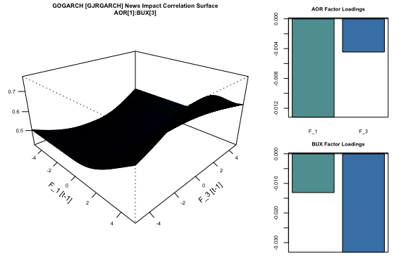

```r
gogarch_mod |> newsimpact(type = "correlation", pair = c(2,5), factor = c(1,3)) |> plot()
```

## Filtering

Online filtering of new data with the existing estimated model can be achieved via the `tsfilter` method which returns an object of class gogarch.estimate updated with the new information. What this allows us to do is to use the existing estimated model in order to filter newly arrived information without having to re-estimate. Since the returned object is the same as the estimated object, we can then use the existing methods to analyze the new data. The next code snippet shows how to perform 1-step ahead rolling predictions and generation of an equal weighted portfolio value at risk at the 10% quantile.

```r
h <- 98
w <- rep(1/5, 5)
gogarch_filter_mod <- gogarch_mod
var_value <- rep(0, 98)
actual <- as.numeric(coredata(test) %*% w)

# first prediction without filtering update
var_value[1] <- predict(gogarch_mod, h = 1, nsim = 5000, seed = 100) |> value_at_risk(weights = w, alpha = 0.1)
for (i in 2:h) {
  gogarch_filter_mod <- tsfilter(gogarch_filter_mod, y = test[i - 1,])
  var_value[i]  <- predict(gogarch_filter_mod, h = 1, nsim = 5000, seed = 100) |> value_at_risk(weights = w, alpha = 0.1)
}
```

At time `T+0` the initial prediction is made for `T+1`, and then the model is updated with new information using the `tsfilter` method bringing the model information set to time `T+1` from which predictions at time `T+2` are made and so forth. This is equivalent to a rolling 1-step ahead rolling prediction without re-estimation.

Having obtained the predicted value at risk from the simulated distribution, we can then use the `var_cp_test` function from the tstests package to evaluate the accuracy of the calculation:

```r
as_flextable(var_cp_test(actual, var_value, alpha = 0.1), include.decision = TRUE)
```

Value at Risk Tests (Christoffersen and Pelletier)

| Test | DoF | Statistic | Pr(>Chisq) |  | Decision(5%) |
| --- | --- | --- | --- | --- | --- |
| Kupiec (UC) | 1 | 1.8739 | 0.1710 |  | Fail to Reject H0 |
| CP (CCI) | 1 | 0.8753 | 0.3495 |  | Fail to Reject H0 |
| CP (CC) | 2 | 2.7493 | 0.2529 |  | Fail to Reject H0 |
| CP (D) | 1 | 0.1147 | 0.7348 |  | Fail to Reject H0 |

Signif. codes: 0 '***' 0.001 '**' 0.01 '*' 0.05 '.' 0.1 ' ' 1  
Coverage: 0.1, Obs: 98, Failures: 6, E[Failures]: 9  
Hypothesis(H0) : Unconditional(UC), Independent(CCI), Joint Coverage(CC) and Duration(D)

## Conditional Co-moments

There are 3 methods related to the conditional co-moments of the model: `tscov` (and `tscor`) returns the `NxNxT` conditional covariance (correlation) matrix, `tscoskew` returns the `NxNxNxT` conditional co-skewewness matrix and `tscokurt` returns the `NxNxNxNxT` conditional co-kurtosis matrix. These methods benefit from the use of multiple threads which can be set via the `RcppParallel::setThreadOptions` function (though care should be taken about availability of RAM).

```r
V <- tscov(gogarch_mod)
S <- tscoskew(gogarch_mod, standardized = TRUE, folded = TRUE)
K <- tscokurt(gogarch_mod, standardized = TRUE, folded = TRUE)
```

Notice that the `standardized` and `folded` arguments are used to return the standardized co-moments in either folded or unfolded form. The unfolded form represented the flattened tensor of the co-moments is useful for the calculation of the portfolio weighted moments via the Kronecker product. Theses method are available for both estimate and predicted/simulated objects. To illustrate this, we also generate a 25 step ahead prediction, generate the co-kurtosis distribution and then combine the estimated and predicted into a `tsmodel.predict` object for which special purpose plots are available from the tsmethods package.

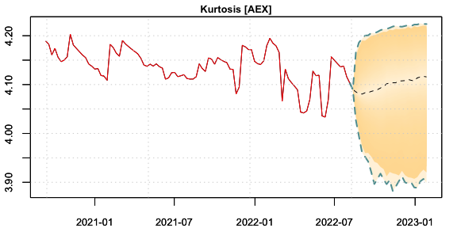

```r
p <- predict(gogarch_mod, h = 25, nsim = 1000, seed = 100)
K_p <- tscokurt(p, standardized = TRUE, folded = TRUE, distribution = TRUE, index = 1:25)
K_p <- t(K_p[1,1,1,1,,])
colnames(K_p) <- as.character(p$forc_dates)
class(K_p) <- "tsmodel.distribution"
L <- list(original_series = xts(K[1,1,1,1,], as.Date(gogarch_mod$spec$target$index)), distribution = K_p)
class(L) <- "tsmodel.predict"
par(mar = c(2,2,1.1,1), pty = "m", cex.axis = 0.8)
plot(L, gradient_color = "orange", interval_color = "cadetblue", median_color = "black", median_type = 2, median_width = 1,
     n_original = 100, main = "Kurtosis [AEX]", xlab = "", cex.main = 0.8)
```

```r
par(oldpar)
```

To calculate the weighted portfolio moments we can use the `tsaggregate` method and similarly form an object for plotting, this time for the portfolio skewness.

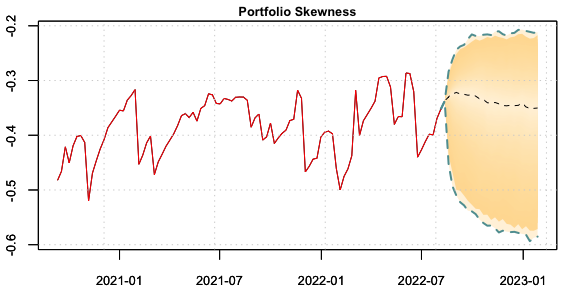

```r
port_moments_estimate <- tsaggregate(gogarch_mod, weights = w)
port_moments_predict <- tsaggregate(p, weights = w, distribution = TRUE)
L <- list(original_series = port_moments_estimate$skewness, distribution = port_moments_predict$skewness)
class(L) <- "tsmodel.predict"
par(mar = c(2,2,1.1,1), pty = "m", cex.axis = 0.8)
plot(L, gradient_color = "orange", interval_color = "cadetblue", median_color = "black", median_type = 2, median_width = 1,
     n_original = 100, main = "Portfolio Skewness", xlab = "", cex.main = 0.8)
```

```r
par(oldpar)
```

## Weighted Portfolio Distribution

The main vignette discusses in detail the convolution approach for generating a weighted portfolio distribution from which the density and quantile functions can then be approximated. A short example is provided below where we evaluate the FFT approximation against the exact moments for a 98-step ahead prediction.

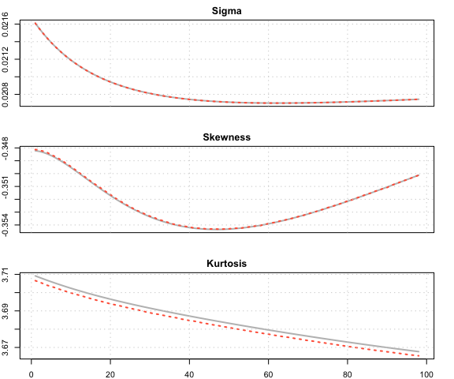

```r
p <- predict(gogarch_mod, h = 98, nsim = 1000)
port_f_moments <- do.call(cbind, tsaggregate(p, weights = w, distribution = FALSE))
pconv <- tsconvolve(p, weights = w, fft_support = NULL, fft_step = 0.0001, fft_by = 0.00001, distribution = FALSE)
p_c_moments <- matrix(0, ncol = 4, nrow = 98)
for (i in 1:98) {
  df <- dfft(pconv, index = i)
  mu <- pconv$mu[i]
  f_2 <- function(x) (x - mu)^2 * df(x)
  f_3 <- function(x) (x - mu)^3 * df(x)
  f_4 <- function(x) (x - mu)^4 * df(x)
  sprt <- attr(pconv$y[[i]],"support")
  p_c_moments[i,2] <- sqrt(integrate(f_2, sprt[1], sprt[2], abs.tol = 1e-8, subdivisions = 500)$value)
  p_c_moments[i,3] <- integrate(f_3, sprt[1], sprt[2], abs.tol = 1e-8, subdivisions = 500)$value/p_c_moments[i,2]^3
  p_c_moments[i,4] <- integrate(f_4, sprt[1], sprt[2], abs.tol = 1e-8, subdivisions = 500)$value/p_c_moments[i,2]^4
}
par(mar = c(2,2,2,2), mfrow = c(3,1), pty = "m")
matplot(cbind(as.numeric(port_f_moments[,2]), p_c_moments[,2]), type = "l", lty = c(1,3), lwd = c(2, 2), col = c("grey","tomato1"), main = "Sigma", xaxt = "n")
grid()
matplot(cbind(as.numeric(port_f_moments[,3]), p_c_moments[,3]), type = "l", lty = c(1,3), lwd = c(2, 2), col = c("grey","tomato1"), main = "Skewness", xaxt = "n")
grid()
matplot(cbind(as.numeric(port_f_moments[,4]), p_c_moments[,4]), type = "l", lty = c(1,3), lwd = c(2, 2), col = c("grey","tomato1"), main = "Kurtosis")
grid()
```

```r
par(oldpar)
```

The next plot shows how to generate a value at risk surface for the prediction period. It should be noted that the sample quantiles from the simulated distribution will not match up to the FFT approximation since the one is based on simulation whereas the other is an analytic approximation to the weighted density.

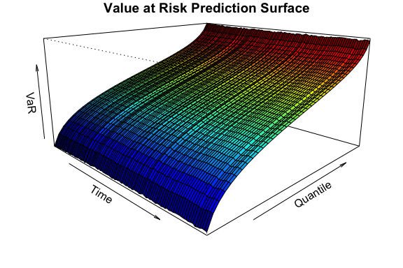

```r
p <- predict(gogarch_mod, h = 98, nsim = 5000)
pconv <- tsconvolve(p, weights = w, fft_support = NULL, fft_step = 0.0001, fft_by = 0.00001, distribution = FALSE)
q_seq <- seq(0.025, 0.975, by = 0.025)
q_surface = matrix(NA, ncol = length(q_seq), nrow = 98)
for (i in 1:98) {
  q_surface[i,] <- qfft(pconv, index = i)(q_seq)
}
par(mar = c(1.8,1.8,1.1,1), pty = "m")
col_palette <- drapecol(q_surface, col = femmecol(100), NAcol = "white")
persp(x = 1:98, y = q_seq, z = q_surface,  col = col_palette, theta = 45,
      phi = 15, expand = 0.5, ltheta = 25, shade = 0.25,
      ticktype = "simple", xlab = "Time", ylab = "Quantile",
      zlab = "VaR", cex.axis = 0.8, main = "Value at Risk Prediction Surface")
```

```r
par(oldpar)
```

We can also generate the probability integral transform of the weighted distribution which can be used in the expected shortfall test:

```r
pit_value <- pit(pconv, actual)
as_flextable(shortfall_de_test(pit_value, alpha = 0.1), include.decision = TRUE)
```

Expected Shortfall Test (Du and Escanciano)

| Test | Statistic | Pr(>\|t\|) |  | Decision(5%) |
| --- | --- | --- | --- | --- |
| DE (U) | 0.0236 | 0.1360 |  | Fail to Reject H0 |
| DE (C) | 3.8466 | 0.0498 |  | Reject H0 |

Signif. codes: 0 '***' 0.001 '**' 0.01 '*' 0.05 '.' 0.1 ' ' 1  
Coverage: 0.1, Obs: 98  
Hypothesis(H0) : Unconditional(U) and Independent(C)

# DCC Dynamics

## Model Specification and Estimation

In the DCC model we need to pre-estimate the univariate dynamics before passing them to the DCC specification as a `multi_garch` class object. With the exception of the Copula model, the marginal distributions of the univariate GARCH models should always be Normal, irrespective of whether a multivariate Normal or Student is chosen as the DCC model distribution. There are no checks performed for this and it is up to the user to ensure that this is the case. Additionally, for the purpose of allowing the calculation of the partitioned Hessian, the argument `keep_tmb` should be set to TRUE in the estimation routine of the univariate models.

```r
garch_model <- lapply(1:5, function(i) {
  garch_modelspec(train[,i], model = "gjrgarch") |> estimate(keep_tmb = TRUE)
})
garch_model <- to_multi_estimate(garch_model)
names(garch_model) <- colnames(train)
```

Once the univariate models have been estimated and converted to the appropriate class, we can then pass the object to the DCC model for estimation:

```r
dcc_mod <- dcc_modelspec(garch_model, dynamics = "adcc", distribution = "mvt") |> estimate()
dcc_mod |> summary()
```

```
#> DCC Model Summary
#> DCC Dynamics: ADCC | MVT
#> Coefficients:
#>         Estimate Std. Error t value Pr(>|t|)
#> alpha_1 0.010269   0.002646   3.880 0.000104 ***
#> gamma_1 0.007613   0.003725   2.044 0.040976 *
#> beta_1  0.972286   0.005412 179.665  < 2e-16 ***
#> shape   9.188384   0.750585  12.242  < 2e-16 ***
#> ---
#> Signif. codes:  0 '***' 0.001 '**' 0.01 '*' 0.05 '.' 0.1 ' ' 1
#>
#> N: 1600 | Series:  5
#> LogLik: 19704.9,  AIC:  -39351.8,  BIC: -39195.9
```

We chose to use `adcc` dynamics for this demo which allows asymmetric reaction to positive and negative shocks, and nicely visualized using a news impact correlation surface plot:

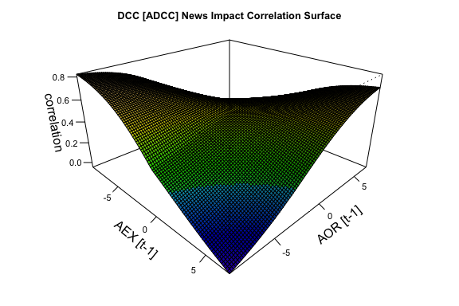

```r
newsimpact(dcc_mod, pair = c(1,2)) |> plot()
```

## Filtering

We perform a similar exercise as in the GOGARCH filtering section:

```r
h <- 98
w <- rep(1/5, 5)
dcc_filter_mod <- dcc_mod
var_value <- rep(0, 98)
actual <- as.numeric(coredata(test) %*% w)
# first prediction without filtering update
var_value[1] <- predict(dcc_mod, h = 1, nsim = 5000, seed = 100) |> value_at_risk(weights = w, alpha = 0.1)
for (i in 2:h) {
  dcc_filter_mod <- tsfilter(dcc_filter_mod, y = test[i - 1,])
  var_value[i]  <- predict(dcc_filter_mod, h = 1, nsim = 5000, seed = 100) |> value_at_risk(weights = w, alpha = 0.1)
}
as_flextable(var_cp_test(actual, var_value, alpha = 0.1), include.decision = TRUE)
```

Value at Risk Tests (Christoffersen and Pelletier)

| Test | DoF | Statistic | Pr(>Chisq) |  | Decision(5%) |
| --- | --- | --- | --- | --- | --- |
| Kupiec (UC) | 1 | 0.3894 | 0.5326 |  | Fail to Reject H0 |
| CP (CCI) | 1 | 0.1847 | 0.6674 |  | Fail to Reject H0 |
| CP (CC) | 2 | 0.5741 | 0.7505 |  | Fail to Reject H0 |
| CP (D) | 1 | 0.0091 | 0.9240 |  | Fail to Reject H0 |

Signif. codes: 0 '***' 0.001 '**' 0.01 '*' 0.05 '.' 0.1 ' ' 1  
Coverage: 0.1, Obs: 98, Failures: 8, E[Failures]: 9  
Hypothesis(H0) : Unconditional(UC), Independent(CCI), Joint Coverage(CC) and Duration(D)

## Weighted Portfolio Distribution

There are 2 ways to obtain the weighted portfolio distribution for the DCC model:

1. Use the simulated distribution and aggregate (method used in `tsaggregate`)
2. Make use of the analytic form for the weighted multivariate Normal and Student distributions.

We illustrate both approaches in a quick prediction exercise:

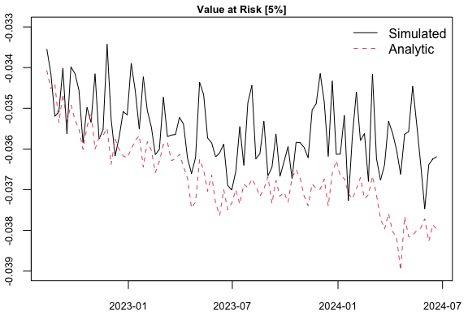

```r
p <- predict(dcc_mod, h = 98, nsim = 5000)
simulated_aggregate <- tsaggregate(p, weights = w, distribution = TRUE)
# we don't have any conditional mean dynamics but uncertainty around zero from the simulation
weighted_mu <- t(apply(p$mu, 1, rowMeans)) %*% w
H <- tscov(p, distribution = FALSE)
weighted_sigma <- sqrt(sapply(1:98, function(i) w %*% H[,,i] %*% w))
shape <- unname(coef(dcc_mod)["shape"])
simulated_var <- unname(apply(simulated_aggregate$mu, 2, quantile, 0.05))
analytic_var <- qstd(0.05, mu = weighted_mu, sigma = weighted_sigma, shape = shape)
par(mar = c(2,2,1.1,1), pty = "m", cex.axis = 0.8, cex.main = 0.8)
plot(as.Date(p$forc_dates), simulated_var, type = "l", ylab = "", xlab = "", main = "Value at Risk [5%]", ylim = c(-0.039, -0.033))
lines(as.Date(p$forc_dates), analytic_var, col = 2, lty = 2)
legend("topright", c("Simulated","Analytic"), col = 1:2, lty = 1:2, bty = "n")
```

```r
par(oldpar)
```

Note that the DCC dynamics do not have a closed form solution for the multi-step ahead forecast. Approximations have been used in the literature but in the `tsmarch` package we have instead opted for a simulation approach which means that when calling the `tscov` method on a predicted object it will either return the full simulated array of covariance matrices else their average across each horizon when the `distribution` argument is set to FALSE.

# Copula with DCC Dynamics

The Copula model allows different distributions for the margins allowing for an additional layer of flexibility. The next sections use the same type of code examples as in the DCC model. Once a model is estimated, the methods applied on the model and all subsequent methods are the same as in the DCC and GOGARCH models.

## Model Specification and Estimation

```r
distributions <- c(rep("jsu",4), rep("sstd",1))
garch_model <- lapply(1:5, function(i) {
  garch_modelspec(train[,i], model = "gjrgarch", distribution = distributions[i]) |> estimate(keep_tmb = TRUE)
})
garch_model <- to_multi_estimate(garch_model)
names(garch_model) <- colnames(train)
```

```r
cgarch_mod <- cgarch_modelspec(garch_model, dynamics = "adcc",
                               transformation = "parametric",
                               copula = "mvt") |> estimate()
cgarch_mod |> summary()
```

```
#> CGARCH Model Summary
#> Copula Dynamics: parametric | MVT | ADCC
#> Coefficients:
#>          Estimate Std. Error t value Pr(>|t|)
#> alpha_1  0.009024   0.001943   4.645 3.40e-06 ***
#> gamma_1  0.010817   0.003077   3.515 0.000439 ***
#> beta_1   0.977253   0.004038 242.008  < 2e-16 ***
#> shape   16.911640   2.711949   6.236 4.49e-10 ***
#> ---
#> Signif. codes:  0 '***' 0.001 '**' 0.01 '*' 0.05 '.' 0.1 ' ' 1
#>
#> N: 1600 | Series:  5
#> LogLik: 19792.3,  AIC:  -39506.7,  BIC: -39297
```

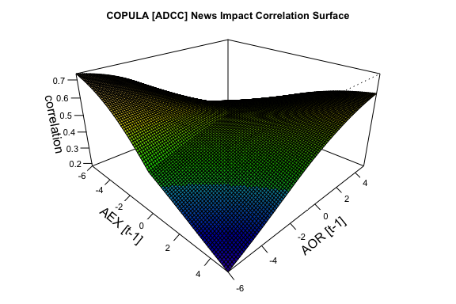

```r
newsimpact(cgarch_mod, pair = c(1,2)) |> plot()
```

## Filtering

```r
h <- 98
w <- rep(1/5, 5)
cgarch_filter_mod <- cgarch_mod
var_value <- rep(0, 98)
actual <- as.numeric(coredata(test) %*% w)
# first prediction without filtering update
var_value[1] <- predict(cgarch_mod, h = 1, nsim = 5000, seed = 100) |> value_at_risk(weights = w, alpha = 0.1)
for (i in 2:h) {
  cgarch_filter_mod <- tsfilter(cgarch_filter_mod, y = test[i - 1,])
  var_value[i]  <- predict(cgarch_filter_mod, h = 1, nsim = 5000, seed = 100) |> value_at_risk(weights = w, alpha = 0.1)
}
as_flextable(var_cp_test(actual, var_value, alpha = 0.1), include.decision = TRUE)
```

Value at Risk Tests (Christoffersen and Pelletier)

| Test | DoF | Statistic | Pr(>Chisq) |  | Decision(5%) |
| --- | --- | --- | --- | --- | --- |
| Kupiec (UC) | 1 | 0.3894 | 0.5326 |  | Fail to Reject H0 |
| CP (CCI) | 1 | 0.1847 | 0.6674 |  | Fail to Reject H0 |
| CP (CC) | 2 | 0.5741 | 0.7505 |  | Fail to Reject H0 |
| CP (D) | 1 | 0.0091 | 0.9240 |  | Fail to Reject H0 |

Signif. codes: 0 '***' 0.001 '**' 0.01 '*' 0.05 '.' 0.1 ' ' 1  
Coverage: 0.1, Obs: 98, Failures: 8, E[Failures]: 9  
Hypothesis(H0) : Unconditional(UC), Independent(CCI), Joint Coverage(CC) and Duration(D)

## Weighted Portfolio Distribution

For the Copula model we reply on the simulated distribution for all calculations:

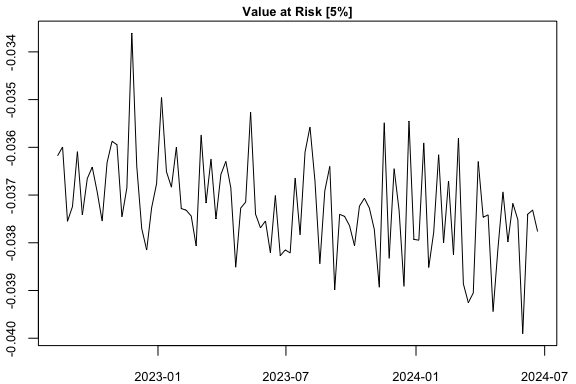

```r
p <- predict(cgarch_mod, h = 98, nsim = 5000)
simulated_aggregate <- tsaggregate(p, weights = w, distribution = TRUE)
simulated_var <- unname(apply(simulated_aggregate$mu, 2, quantile, 0.05))
par(mar = c(2,2,1.1,1), pty = "m", cex.axis = 0.8, cex.main = 0.8)
plot(as.Date(p$forc_dates), simulated_var, type = "l", ylab = "", xlab = "", main = "Value at Risk [5%]")
```

```r
par(oldpar)
```

# Conditional Mean Dynamics

We briefly address in this section the question of how to handle conditional mean dynamics. There are effectively 2 approaches which are available for the user:

1. Pass in the `cond_mean` at every stage of the analysis (i.e. estimation, prediction, filtering, simulation etc) and the underlying code will take care of re-centering the simulated distributions.
2. Do not pass anything for the `cond_mean` but then take the predicted simulated zero mean correlated residuals use them as inputs to the prediction method of the conditional mean dynamics.

Whilst the second method may be preferred, not many packages have either an option for generating a simulated predictive distribution or taking an input of a pre-created matrix of correlated residuals. In the next section we illustrate both approaches.

## Method 1: Conditional Mean Re-centering

We first estimate the conditional mean dynamics using an AR(6) model, extract the residuals and fitted values and then make a 25 step ahead prediction.

```r
arima_model <- lapply(1:5, function(i){
  arima(train[,i], order = c(6,0,0), method = "ML")
})
.residuals <- do.call(cbind, lapply(arima_model, function(x) as.numeric(residuals(x))))
colnames(.residuals) <- colnames(train)
.residuals <- xts(.residuals, index(train))
.fitted <- train - .residuals
.predicted <- do.call(cbind, lapply(1:5, function(i){
  as.numeric(predict(arima_model[[i]], n.ahead = 25)$pred)
}))
colnames(.predicted) <- colnames(train)
```

We then pass the .fitted values to the estimation method and the .predicted valued to the prediction method. Technically, the estimation method does not require this if we are only interested in prediction since they will not be used. All 3 models in the package handle the conditional mean inputs in the same way, ensuring that the output generated from different methods which depends on this will be correctly reflected. For this example we will use the DCC model:

```r
dcc_mod_mean <- dcc_modelspec(garch_model, dynamics = "adcc", distribution = "mvt", cond_mean = .fitted) |> estimate()
all.equal(fitted(dcc_mod_mean), .fitted)
```

```
#> [1] TRUE
```

As expected the fitted method now picks up the `cond_mean` passed to the model.

```r
p <- predict(dcc_mod_mean, h = 25, cond_mean = .predicted, nsim = 5000, seed = 100)
simulated_mean <- as.matrix(t(apply(p$mu, 1, rowMeans)))
colnames(simulated_mean) <- colnames(train)
all.equal(simulated_mean, .predicted)
```

```
#> [1] TRUE
```

The mean of the simulated predictive distribution for each series and horizon is now the same as the matrix passed (.predicted) as a result of the re-centering operation automatically carried out.

## Method 2: Innovation Distribution Injection

In the injection approach, we pass the simulated correlated innovations from the DCC model to the ARIMA simulation and ensure that we also pass enough start-up innovations to produce a forward type simulation equivalent to a simulated forecast.

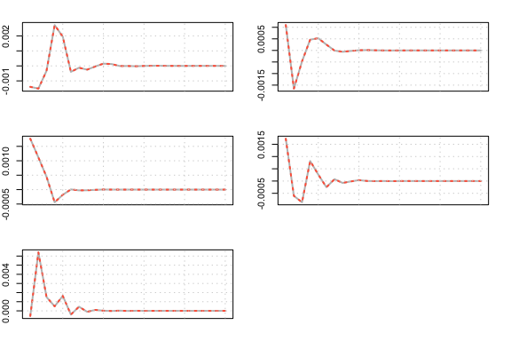

```r
res <- p$mu
arima_pred <- lapply(1:5, function(i){
  # we eliminate the mean prediction from the simulated predictive distribution
  # to obtain the zero mean innovations
  res_i <- scale(t(res[,i,]), scale = FALSE, center = TRUE)
  sim_p <- do.call(rbind, lapply(1:5000, function(j) {
    arima.sim(model = list(ar = coef(arima_model[[i]])[1:6]), n.start = 20, n = 25, innov = res_i[j,], start.innov = as.numeric(tail(.residuals[,i],20))) |> as.numeric() + coef(arima_model[[i]])[7]
  }))
  return(sim_p)
})
arima_pred <- array(unlist(arima_pred), dim = c(5000, 25, 5))
arima_pred <- aperm(arima_pred, c(2, 3, 1))

simulated_mean <- as.matrix(t(apply(arima_pred, 1, rowMeans)))
colnames(simulated_mean) <- colnames(train)
par(mfrow = c(3,2), mar = c(2,2,2,2))
for (i in 1:5) {
  matplot(cbind(simulated_mean[,i], .predicted[,i]), type = "l", lty = c(1,3), lwd = c(2, 2), col = c("grey","tomato1"), ylab = "", xaxt = "n")
  grid()
}
par(oldpar)
```

The simulated mean is as expected no different from the prediction mean of the ARIMA model.

## Method Comparison

We visually inspect the 2 methods by creating a couple of overlayed distribution plots

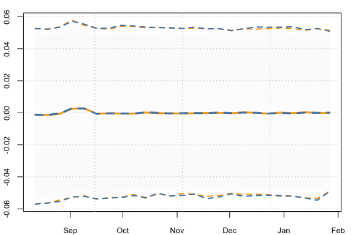

```r
i <- 1
sim_1a <- t(p$mu[,i,])
sim_1b <- t(arima_pred[,i,])
colnames(sim_1a) <- colnames(sim_1b) <- as.character(p$forc_dates)
class(sim_1a) <- class(sim_1b) <- "tsmodel.distribution"
par(mar = c(2,2,1.1,1), pty = "m", cex.axis = 0.8)
plot(sim_1a, gradient_color = "whitesmoke", interval_color = "orange", median_color = "orange")
plot(sim_1b, add = TRUE, gradient_color = "whitesmoke", interval_color = "steelblue", median_color = "steelblue", median_type = 2)
```

```r
par(oldpar)
```

Next we visually inspect the pairwise correlations between the two methods:

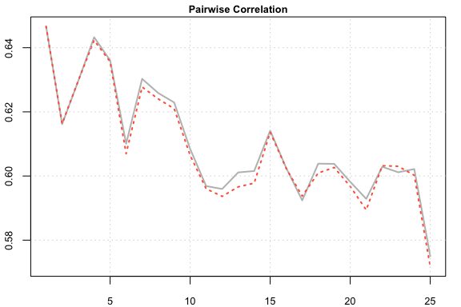

```r
j <- 2
sim_2a <- t(p$mu[,j,])
sim_2b <- t(arima_pred[,j,])
colnames(sim_2a) <- colnames(sim_2b) <- as.character(p$forc_dates)
class(sim_2a) <- class(sim_2b) <- "tsmodel.distribution"
C_a <- sapply(1:25, function(i) cor(sim_1a[,i], sim_2a[,i]))
C_b <- sapply(1:25, function(i) cor(sim_1b[,i], sim_2b[,i]))
par(mar = c(2,2,1.1,1), pty = "m", cex.axis = 0.8, cex.main = 0.8)
matplot(cbind(C_a, C_b), type = "l", lty = c(1,3), lwd = c(2, 2), col = c("grey","tomato1"), ylab = "", main = "Pairwise Correlation")
grid()
```

```r
par(oldpar)
```

As can be observed, both methods produce almost identical output.